# Applied Psychophysics

Mats E. Nilsson

# **Notes Seminar 4** (2017-10-31)

### Reminder: Reading instructions (from Notes Seminar 1)

- Seminar 1. Introduction to psychophysics
- Seminar 2. Key concepts and distinctions (K&N, Chs. 2-3)
- Seminar 3. Psychometric functions (K&N, Ch. 4; K&M, Chs. 4-5)
- Seminar 4. Adaptive methods (K&N, Ch. 5)
- Seminar 5. SDT, fundamentals (K&N, Ch. 6)
- Seminar 6. SDT, simulation (K&M, Ch. 3)

## Adaptive staircase methods

Data from adaptive 2-down-1-up staircase measuring *discrimination* threshold, using a 2AFC method.

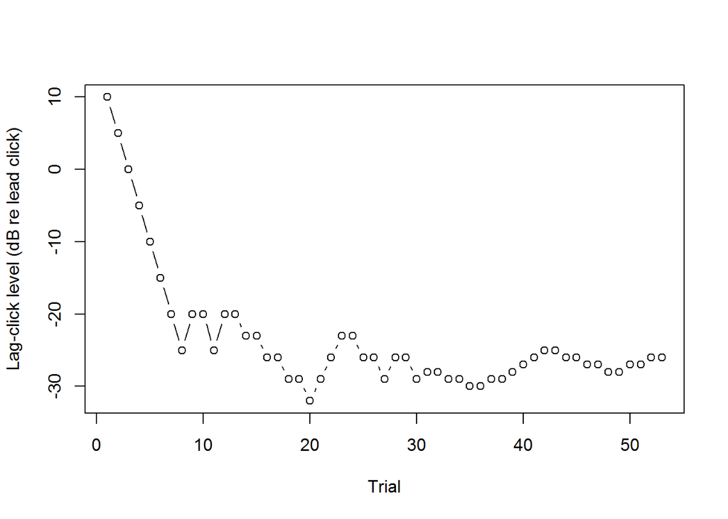

**Variants** (first four non-parametric, last three parametric)

- Simple up/down (1-up-1-down)
- Transformed up/down (e.g., 1-up-2-down)
- Weighted up/down (1-up-1-down but differetn size up and down)
- Transformed Weighted up/down (e.g., 1-up-2-down, and different size up and down)
- Best PEST
- Best QUEST
- Psi

**How to analyze**

- Non-parametric: Mean of specified number of trials (e.g., last n reversals)
- Parametric: Lump all data together and fit a psychometric function (at least 400 trials recommended by K&P)

Fit psychometric function to all data

```
## threshold     scale
## -26.25105  11.08173
```

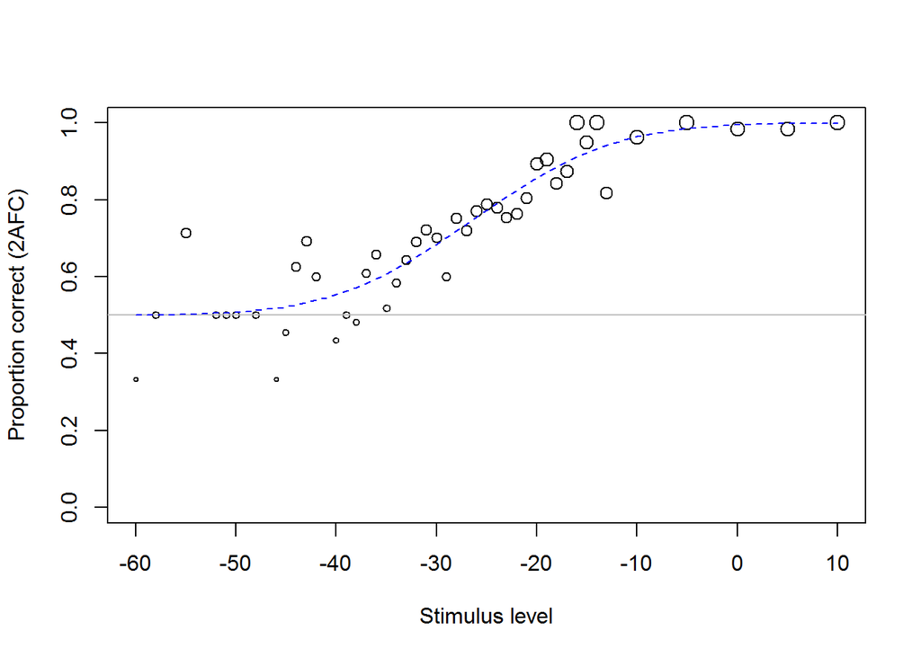

## Design decisions

- Staircase rule, e.g., 2AFC-weighted step sizes
- Step sizes: linear or log
- Step sizes: Fixed or diminishing, large steps to zoom in, then small steps
- Stop rule: Fixed number of trials, fixed number o reversals, fixed number of small reversals, confidence limits of estimates (parametric methods), …
- Summary rule: Average of all trials, average of all reversals, value at last reversal, …